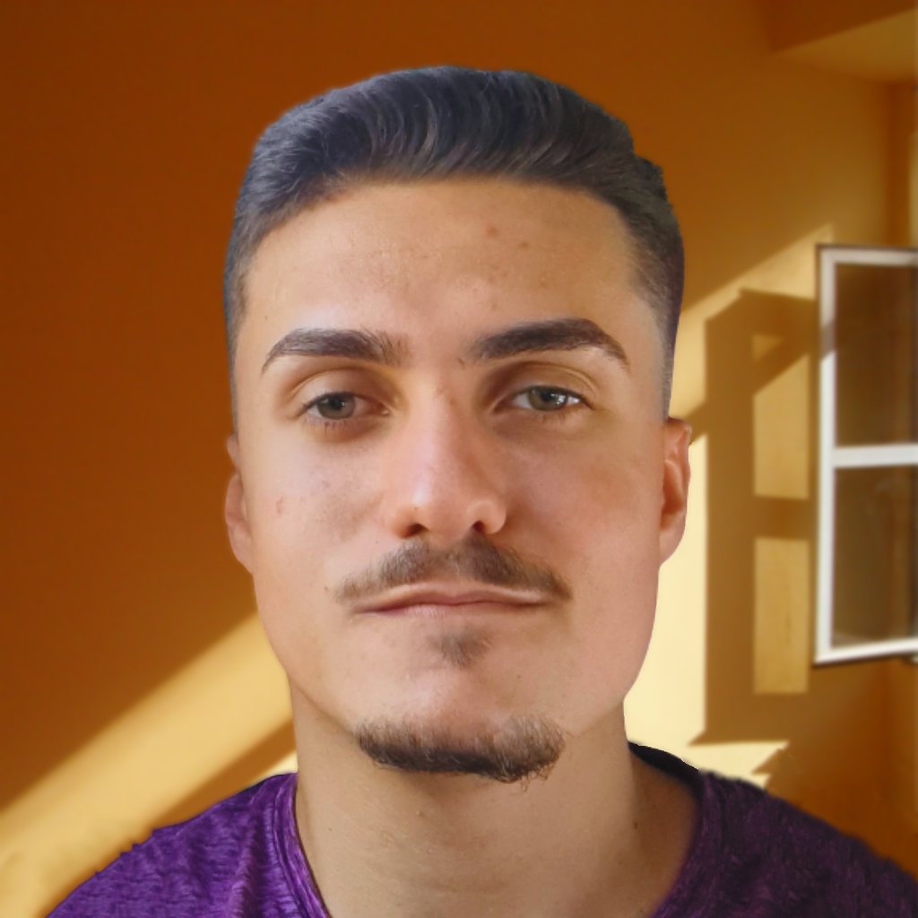

# Andre Barboza Farias

## > Sobre:

Estudante de Eng.Mecatrônica na UFSJ apaixonado pela tecnologia. Proativo e com grande potêncial em liderança. Com muito esforço e determinação, busca cada dia mais o desenvolvimento do seu acervo profissional. Deseja sempre o bem estar coletivo, gerando um ambiente agradavel e de grande produtividade. O âmbito acadêmico tem mostrado que a cada dia algo novo pode ser descoberto, barreiras sempre são quebradas, nada é impossivel ao seu ponto de vista, luta, conquista e sonha por um grande futuro profissional e familiar.

## > Educação:

**Universidade Federal de São João del-Rei (UFSJ)** | Ouro Branco, MG

Bacharelado | Engenharia Mecatrônica | Setembro 2020 - Setembro 2027

Certificado | R (Básico - Intermediario) | Setembro 2020 - Junho 2021

**Serviço Nacional de Aprendizagem Comercial (SENAC)** | Rio de Janeiro, RJ

Profissionalizante | Operador de Computador | Setembro 2019 - Julho 2021

**SENAC** & **Cisco Academy** | Rio de Janeiro, RJ

Certificado | I.T. Essentials | Setembro 2020 - Maio 2021

## > Desenvolvimento(T.I.):

### Linguagens

**R** | **TCL/TK** | **Python** | **C** | **C++** | **C#** | **HTML/CSS/JAVASCRIPT** | **GIT** | **Assembly** | **SQL**.

### Softwares:

- AutoCAD;
- Blender
- Cinema4D
- Sony Vegas;
- Adobe After Effect;
- Adobe Premiere;
- Adobe Photoshop;
- Office FULL;
- PowerBi;
- SQL Server;
- Unity;
- Unreal Engine;
- Linux;
- GNS3;
- Virtual Box;
- Outros…

## > Projetos:

- [Leem](https://github.com/andrebzf/leem)- Laboratório de Estatística e Matemática | Julho 2022 - Atual:

  Com o crescente avanço do ensino remoto ou ensino à distância (online), após pandemia, procuramos diversas formas de suprir a aprendizagem no ensino presencial. Diante disso, publicamos recentemente o pacote leem (ALMEIDA, 2022; BATISTA; ALMEIDA, 2022), no ambiente R, como uma ferramenta auxiliar para o ensino da estatística e matemática para o ensino fundamental e superior. Com a implementação de uma interface gráfica, o usuário é capaz de utilizar o leem sem a necessidade de programar em R. Até o momento, a interface do leem foi desenvolvida (BATISTA, 2022), em sua versão 0.1.0, com pequenas implementações de atividades do ensino fundamental para a área da matemática. Diante da necessidade de auxiliar as atividades desenvolvidas para o ensino da estatística, modalidade ensino superior, desenvolveremos ferramentas para o estudo introdutório da Estatística Básica, que compreende, a organização, tabulação, apresentação gráfica, bem como as medidas resumo.
- [Statscience](https://github.com/andrebzf/statscience)- Estatística e Análise de Dados | Dezembro 2022 - Atual:

  Esse projeto tem por objetivo, criar um pacote à ser utilizado na linguagem R, para aplicação de conceitos estatísticos na análise de dados, ou Data Science. Sâo abordados diversos conceitos como BigData, SQL e mais.
- **Bussines Inteligence** - Pequenas Empresas Inteligentes | Setembro 2019 - Março 2020:

  Neste projeto foram desenvolvidas técnicas para uso de aplicativos e ferramentas que auxiliaram pequenas empresas da rede SENAC a gerenciar e organizar a saida e entrada de produtos, atendimento ao cliente e melhores resultados financeiros das mesmas.

Continua em breve…

“Desempenhe o melhor”. -Andre Barboza Farias